# Assessment of US Storm Hazards - the Most Damaging Events

## Synopsis

I explore **the U.S. National Oceanic and Atmospheric Administration’s (NOAA) storm database** to establish which events have the biggest impact on U.S. population health and economy. The dataset is checked for major errors and these are corrected. Events are assigned to types that are partially standardized.

The results show that **tornades** are by far the most detrimental for the population health. **Thunderstorm winds, excessive heat and floods** follow but their impact is several times smaller. In terms of economic impact **hurricanes** incur the biggest damage, followed by **tornadoes, storm surges/tides and floods**.

## Data Processing

### Reading and checking the data

#### Reading data

```r
file <- "StormData.csv.bz2"
data <- read.csv(file)
```

#### Checking Event Type Column

```r
str(data$EVTYPE)
```

```
##  Factor w/ 985 levels "   HIGH SURF ADVISORY",..: 834 834 834 834 834 834 834 834 834 834 ...
```

985 is too much. Official list contains only 48 event types. Following offical event list is taken from the [Storm Data Preparation directive](https://d396qusza40orc.cloudfront.net/repdata%2Fpeer2_doc%2Fpd01016005curr.pdf), p.6:

```r
events <- read.table("event_list_raw.txt", sep=";", col.names = "Event.Type")
sapply(events, function(x) substr(x, 1, regexpr(" [A-Z]$", x) - 1))
```

```
##       Event.Type
##  [1,] "Astronomical Low Tide"
##  [2,] "Avalanche"
##  [3,] "Blizzard"
##  [4,] "Coastal Flood"
##  [5,] "Cold/Wind Chill"
##  [6,] "Debris Flow"
##  [7,] "Dense Fog"
##  [8,] "Dense Smoke"
##  [9,] "Drought"
## [10,] "Dust Devil"
## [11,] "Dust Storm"
## [12,] "Excessive Heat"
## [13,] "Extreme Cold/Wind Chill"
## [14,] "Flash Flood"
```

[output cut: 34 more lines]

Event list should be standardized to conform to the offical list before one can decide which event types make the biggest impact. For this end I don’t apply any automatic string transformation. Instead I use a **manual method**:

1. selecting the EVTYPE’s of the biggest impact on health or economy
2. standardizing them
3. recalculating impact for these standardized event types

To be sure this approach allows corret identification of the most deterimental event types I will compare the resulting ordering of event types with the impact of the left out, unstandardize EVTYPE’s. We will check if standardizing these other EVTYPE’s might change the ordering at the top of the even type list.

To apply this method I need to **first check and clean the numerical measures of damage**.

#### Checking Exponents

The numerical values describing damage are also doubtful in many cases. To correct the errors I **check the top highest numbers** as these have the biggest impact on the ordering of event types.

##### 1. Checking PROPDMGEXP

Let’s print and review the exponent values.

```r
unique(data$PROPDMGEXP)
```

```
##  [1] K M   B m + 0 5 6 ? 4 2 3 h 7 H - 1 8
## Levels:  - ? + 0 1 2 3 4 5 6 7 8 B h H K m M
```

We see the some checking and cleaning should be done:

- check the biggest exponents i.e. B,8,7
- change letters into numbers
- change “ ” (space) into 0
- eliminate characters like -,+,?

Checking PROPDMGEXP == B:

```r
table(data[data$PROPDMGEXP=='B',]$PROPDMG)
```

```
##
##   0.1     1  1.04   1.2   1.3   1.5   1.6   1.7   1.8     2  2.09   2.1
##     1     6     1     1     1     4     1     1     1     1     1     1
##   2.5   2.8     3     4  4.83     5  5.15  5.42  5.88  7.35    10 11.26
##     2     1     2     3     1     2     1     1     1     1     1     1
## 16.93  31.3   115
##     1     1     1
```

Let’s check the extreme PROPDMG=115 case (115*10^9, the biggest value):

```r
data[data$PROPDMGEXP=='B' & data$PROPDMG==115,]
```

```
##        STATE__         BGN_DATE    BGN_TIME TIME_ZONE COUNTY COUNTYNAME
## 605953       6 1/1/2006 0:00:00 12:00:00 AM       PST     55       NAPA
##        STATE EVTYPE BGN_RANGE BGN_AZI BGN_LOCATI         END_DATE
## 605953    CA  FLOOD         0         COUNTYWIDE 1/1/2006 0:00:00
##           END_TIME COUNTY_END COUNTYENDN END_RANGE END_AZI END_LOCATI
## 605953 07:00:00 AM          0         NA         0         COUNTYWIDE
##        LENGTH WIDTH  F MAG FATALITIES INJURIES PROPDMG PROPDMGEXP CROPDMG
## 605953      0     0 NA   0          0        0     115          B    32.5
##        CROPDMGEXP WFO          STATEOFFIC ZONENAMES LATITUDE LONGITUDE
## 605953          M MTR CALIFORNIA, Western               3828     12218
##        LATITUDE_E LONGITUDE_
## 605953       3828      12218
##                                                                                                                                                                                                                                                                                                          …
## 605953 Major flooding continued into the early hours of January 1st, before the Napa River finally fell below flood stage and the water receeded. Flooding was severe in Downtown Napa from the Napa Creek and the City and Parks Department was hit with $6 million in damage alone. The City of Napa ha…
##        REFNUM
## 605953 605943
```

It looks like **it’s an error and should be M instead of B**. I checked other top values for exponents B, 8, 7, 6 and they look fine.

##### 2. Checking CROPDMGEXP

```r
unique(data$CROPDMGEXP)
```

```
## [1]   M K m B ? 0 k 2
## Levels:  ? 0 2 B k K m M
```

I checked several of the highest values here and they seem OK.

#### Checking values of property and crop damages

##### 1. Checking PROPDMG

```r
summary(data$PROPDMG)
```

```
##    Min. 1st Qu.  Median    Mean 3rd Qu.    Max.
##    0.00    0.00    0.00   12.06    0.50 5000.00
```

Values >= 1000 with exponent attached looks suspicious. Let’s check them:

```r
cond <- data$PROPDMG>=1000
dc <- data[cond,]
table(dc$PROPDMG)
```

```
##
## 1000 1584 3000 3200 3500 4410 4800 5000
##   10    1    3    1    1    1    1    4
```

```r
dc <- dc[order(dc$PROPDMG,decreasing=TRUE),]
dc[1,]
```

```
##        STATE__          BGN_DATE    BGN_TIME TIME_ZONE COUNTY COUNTYNAME
## 778568      37 7/26/2009 0:00:00 08:11:00 PM       EST     69   FRANKLIN
##        STATE            EVTYPE BGN_RANGE BGN_AZI BGN_LOCATI
## 778568    NC THUNDERSTORM WIND         1     WNW  STALLINGS
##                 END_DATE    END_TIME COUNTY_END COUNTYENDN END_RANGE
## 778568 7/26/2009 0:00:00 08:13:00 PM          0         NA         0
##        END_AZI END_LOCATI LENGTH WIDTH  F MAG FATALITIES INJURIES PROPDMG
## 778568                         0     0 NA  50          0        0    5000
##        PROPDMGEXP CROPDMG CROPDMGEXP WFO              STATEOFFIC
## 778568          K       0          K RAH NORTH CAROLINA, Central
##                                                                                                                                                                                                       ZONENAMES
## 778568
##        LATITUDE LONGITUDE LATITUDE_E LONGITUDE_
## 778568     3604      7810          0          0
##                                                                                                                                                                                                                                                                                                          …
## 778568 EPISODE NARRATIVE: Showers and thunderstorms developed in the afternoon and evening along a surface trough across central North Carolina, in a warm and moist atmosphere. A mid level shear axis crossed the area during the evening helping to intensive the thunderstorms. Some of the thunderst…
##        REFNUM
## 778568 778558
```

Checking all 22 records with PROPDMG>=1000 shows that all have K exponent. I guess **it’s an error and there should either be 5*10^3 or 5000*10^0**. This should be corrrected.

##### 2. Checking CROPDMG

```r
summary(data$CROPDMG)
```

```
##    Min. 1st Qu.  Median    Mean 3rd Qu.    Max.
##   0.000   0.000   0.000   1.527   0.000 990.000
```

There are no values above 1000. I checked some top values and they look fine.

##### 3. Other checks

Other checks show that there are plenty of cases where DMGEXP>0 but no DMG value is provided, both for PROP and CROP. I assume the DMG **in such cases should be corrected to 1**.

### Correcting the data

#### Correcting numerical values

##### 1. Replacing B exponent with M in one case

```r
d1 <- subset(data, select = c(EVTYPE,FATALITIES,INJURIES,PROPDMG,PROPDMGEXP,CROPDMG,CROPDMGEXP))
d1[d1$PROPDMGEXP=='B' & d1$PROPDMG==115,]$PROPDMGEXP <- 'M'
```

##### 2. Setting exponent=0 for PROPDMG >= 1000

```r
d1[d1$PROPDMG >= 1000,]$PROPDMGEXP <- 0
```

##### 3. Setting exponents==’’ to 0

```r
d1[d1$PROPDMGEXP=='',]$PROPDMGEXP <- 0
d1[d1$CROPDMGEXP=='',]$CROPDMGEXP <- 0
```

##### 4. Replacing letters in exponents with numbers

```r
library(plyr)
exponent_fix <- function (x) {
    mapvalues(x,
              from=c('+','-','?','h','H','k','K','m','M','b','B'),
              to = c(NA, NA, NA, '2','2','3','3','6','6','9','9')
    )
}
d1$PROPDMGEXP = exponent_fix(d1$PROPDMGEXP)
d1$CROPDMGEXP = exponent_fix(d1$CROPDMGEXP)
```

##### 5. Eliminating observations with missing values

Some of these observations might be partially complete but I accept this. There are 21 observations to be removed.

```r
d1 <- na.omit(d1)
```

##### 6. Changing exponents from factors to numbers

```r
d1$PROPDMGEXP <- as.numeric(levels(d1$PROPDMGEXP)[d1$PROPDMGEXP])
d1$CROPDMGEXP <- as.numeric(levels(d1$CROPDMGEXP)[d1$CROPDMGEXP])
```

##### 7. Setting DMG=1 where DMG==0 but DMGEXP>0.

There are 197250 such cases for PROP and 261774 for CROP

```r
d1[d1$PROPDMGEXP!=0 & d1$PROPDMG==0,]$PROPDMG <- 1
d1[d1$CROPDMGEXP!=0 & d1$CROPDMG==0,]$CROPDMG <- 1
```

##### 8. Calculating numerical value of the damages

```r
d1$PROPDMGVAL <- d1$PROPDMG*10^d1$PROPDMGEXP
d1$CROPDMGVAL <- d1$CROPDMG*10^d1$CROPDMGEXP
```

#### Standardizing the Event Type

Once we have the numerical values for damage calculate we can finally standardize the Event Type variable.

##### 1. Ordering the EVTYPE categories by their impacts.

```r
d_ft <- aggregate(FATALITIES~EVTYPE, data=d1, sum)
d_in <- aggregate(INJURIES~EVTYPE, data=d1, sum)
d_pr <- aggregate(PROPDMGVAL~EVTYPE, data=d1, sum)
d_cr <- aggregate(CROPDMGVAL~EVTYPE, data=d1, sum)

dft <- d_ft[order(d_ft$FATALITIES, decreasing=TRUE),]
din <- d_in[order(d_in$INJURIES, decreasing=TRUE),]
dpr <- d_pr[order(d_pr$PROPDMGVAL, decreasing=TRUE),]
dcr <- d_cr[order(d_cr$CROPDMGVAL, decreasing=TRUE),]

dft$EVTYPE <- as.character(dft$EVTYPE)
din$EVTYPE <- as.character(din$EVTYPE)
dpr$EVTYPE <- as.character(dpr$EVTYPE)
dcr$EVTYPE <- as.character(dcr$EVTYPE)
```

##### 2. Selecting the top EVTYPE categories to be standardized.

Plotting EVTYPE’s impact on health (FATALITIES, INJURIES) and economy (Property Damage, Crop Damage).

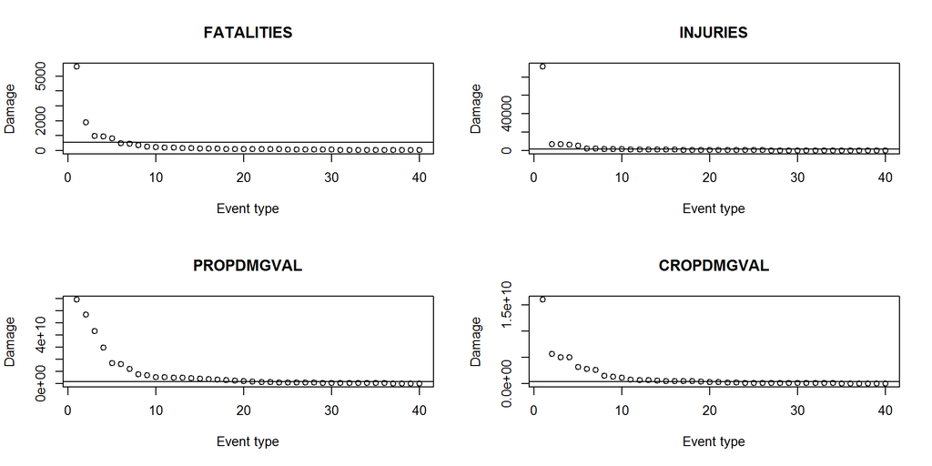

```r
plot_damage <- function(df,n=nrow(df)) {
    all_other <- if(n < nrow(df)) sum(df[(n+1):nrow(df),2]) else 0
    ymax = max(df[1,2], all_other)
    plot(df[1:n,2], main=names(df)[2], ylab="Damage", xlab="Event type", ylim=c(0, ymax))
    if(all_other > 0) abline(h=all_other)
}
par(mfrow=c(2,2))
n = 40
plot_damage(dft, n)
plot_damage(din, n)
plot_damage(dpr, n)
plot_damage(dcr, n)
```

The plot shows the damage for top 40 EVTYPE’s for each damage indicator. The horizontal line shows combined damage of all the other EVTYPE’s. It seems that **it’s enough to standardize the top 40 EVTYPE’s to account for the major event types**. The comined damage of the other EVTYPE’s shouldn’t change the top event types ordering.

Here are all the relevant events:

```r
selected_events = sort(unique(c(
    dft[1:n,1],
    din[1:n,1],
    dpr[1:n,1],
    dcr[1:n,1])))
selected_events
```

```
##  [1] "AGRICULTURAL FREEZE"        "AVALANCHE"
##  [3] "BLIZZARD"                   "COASTAL FLOOD"
##  [5] "COASTAL FLOODING"           "COLD"
##  [7] "COLD AND WET CONDITIONS"    "COLD/WIND CHILL"
##  [9] "Damaging Freeze"            "DAMAGING FREEZE"
## [11] "DENSE FOG"                  "DROUGHT"
## [13] "DUST STORM"                 "Early Frost"
## [15] "EXCESSIVE HEAT"             "EXCESSIVE WETNESS"
## [17] "EXTREME COLD"               "EXTREME COLD/WIND CHILL"
## [19] "EXTREME HEAT"               "FLASH FLOOD"
## [21] "FLASH FLOOD/FLOOD"          "FLASH FLOODING"
## [23] "FLOOD"                      "FLOOD/FLASH FLOOD"
## [25] "FLOOD/RAIN/WINDS"           "FOG"
## [27] "FREEZE"                     "FROST"
## [29] "FROST/FREEZE"               "GLAZE"
```

[output cut: 23 more lines]

There are 76 of them. We write them into file and create a dictionary where each EVTYPE on a list have a standardized Event Type. Additionally we add “Other” event type to simplify subsequent calculations.

##### 3. Creating EVTYPE list, standardizing it and creating dictionary from the former to the latter

I wrote the 76 EVTYPE’s into a file and created a dictionary by assigining each of these EVTYPE’s a standardized name.

```r
write.table(selected_events, file="dict_keys.txt", row.names=F, col.names=F)
write.table(events_clean, file="events_clean.txt", row.names=F, col.names=F)
dict = read.table(file="dict.txt", stringsAsFactors = F, col.names=c("EVTYPE","EVENT_TYPE"))
dict
```

```
##                        EVTYPE              EVENT_TYPE
## 1         AGRICULTURAL FREEZE            Frost/Freeze
## 2                   AVALANCHE               Avalanche
## 3                    BLIZZARD                Blizzard
## 4               COASTAL FLOOD           Coastal Flood
## 5            COASTAL FLOODING           Coastal Flood
## 6                        COLD         Cold/Wind Chill
## 7     COLD AND WET CONDITIONS         Cold/Wind Chill
## 8             COLD/WIND CHILL         Cold/Wind Chill
## 9             Damaging Freeze            Frost/Freeze
## 10            DAMAGING FREEZE            Frost/Freeze
## 11                  DENSE FOG               Dense Fog
## 12                    DROUGHT                 Drought
## 13                 DUST STORM              Dust Storm
## 14                Early Frost            Frost/Freeze
```

[output cut: 63 more lines]

Confirming that the dictionary contains all the selected EVTYPE’s:

```r
all(sapply(selected_events, function(x) x %in% dict$EVTYPE))
```

```
## [1] TRUE
```

##### 4. Standardizing event types in the data

EVENT_TYPE column contains the standardized name for each EVTYPE in the data.

```r
standardize_event_types <- function(df, n = nrow(df)) {
    for(i in 1:nrow(df)) {
        if(!any(dict$EVTYPE==df[i,"EVTYPE"])) {
            df[i,"EVTYPE"] = "other"
        }
    }
    transform(df[1:n,], EVENT_TYPE = mapvalues(df$EVTYPE, dict$EVTYPE, dict$EVENT_TYPE))
}
dftst <- standardize_event_types(dft)
dinst <- standardize_event_types(din)
dprst <- standardize_event_types(dpr)
dcrst <- standardize_event_types(dcr)
```

#### Final data aggregating

Now I aggregate event data and sum up health and economic damages. Event types are sorted by their impact. The “Other” categories are moved to the last rows of the data frames.

```r
dftf <- aggregate(FATALITIES~EVENT_TYPE, data=dftst, sum)
dinf <- aggregate(INJURIES~EVENT_TYPE, data=dinst, sum)
dprf <- aggregate(PROPDMGVAL~EVENT_TYPE, data=dprst, sum)
dcrf <- aggregate(CROPDMGVAL~EVENT_TYPE, data=dcrst, sum)
# final sorting
dftfs <- dftf[order(dftf$FATALITIES, decreasing=TRUE),]
dinfs <- dinf[order(dinf$INJURIES, decreasing=TRUE),]
dprfs <- dprf[order(dprf$PROPDMGVAL, decreasing=TRUE),]
dcrfs <- dcrf[order(dcrf$CROPDMGVAL, decreasing=TRUE),]
# moving "other" to the last row
put_other_at_the_end <- function(df) {
    n = nrow(df)
    other = which(df$EVENT_TYPE=="other")
    if(other>1 & other<n)
        index = c(1:(other-1),(other+1):n,other)
    else if (other==1)
        index = c(2:n,other)
    else
        index = 1:n
    df[index,]
}
dftfs <- put_other_at_the_end(dftfs)
dinfs <- put_other_at_the_end(dinfs)
dprfs <- put_other_at_the_end(dprfs)
dcrfs <- put_other_at_the_end(dcrfs)
```

Let’s plot the most damageing event types for each damage indicator.

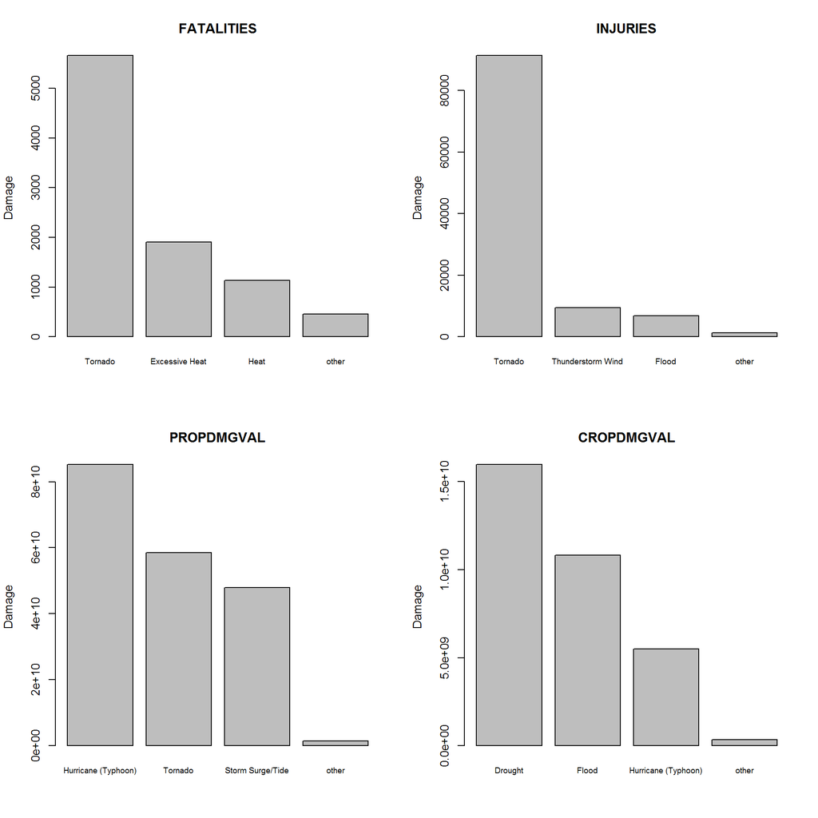

```r
par(mfrow=c(2,2))
barplot_with_the_last_record <- function(df, col, n=3) {
    m = nrow(df)
    if(n==m)
        barplot(height = df[,col], names.arg = df$EVENT_TYPE, cex.names=0.7, main=col, ylab="Damage")
    else
        barplot(height = df[c(1:n,m),col], names.arg = df$EVENT_TYPE[c(1:n,m)], cex.names=0.7, main=col, ylab="Damage")
}
barplot_with_the_last_record(dftfs,"FATALITIES")
barplot_with_the_last_record(dinfs,"INJURIES")
barplot_with_the_last_record(dprfs,"PROPDMGVAL")
barplot_with_the_last_record(dcrfs,"CROPDMGVAL")
```

The plot shows the resulting ordering of event types. We see that **the nonstandardized EVTYPE’s combined under “other” category can’t change the top ordering of event types**.

## Results

Let’s plot event types of the highest health and economic impact.

```r
library(tidyr)
library(dplyr)
bind_rows(dftfs, dinfs, dprfs, dcrfs) %>%
    gather(dimension, damage, -EVENT_TYPE) %>%
    na.omit %>%
    spread(dimension, damage) %>%
    as.data.frame -> d
rownames(d) <- d$EVENT_TYPE
d <- subset(d,select=-EVENT_TYPE)
```

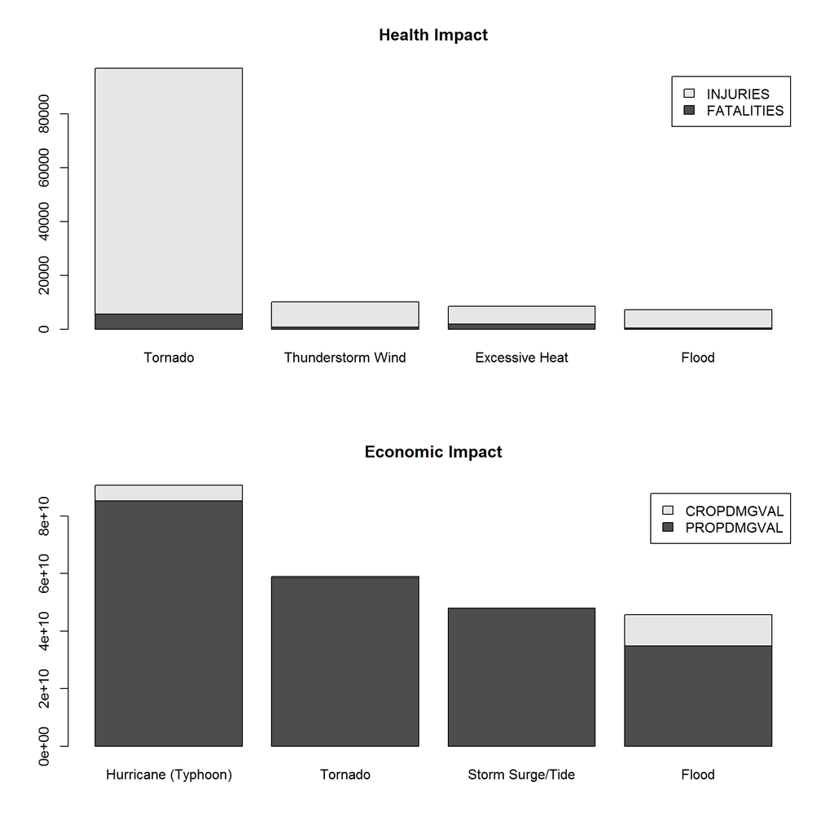

```r
n <- 4
par(mfrow=c(2,1))
hc <- c('FATALITIES','INJURIES')
human <- data.frame(value=rowSums(d[,hc]))
barplot(t(as.matrix(d[order(human$value,decreasing=T)[1:n],hc])),legend=hc,main="Health Impact")
ec <- c('PROPDMGVAL','CROPDMGVAL')
econ <- data.frame(value=rowSums(d[,ec]))
barplot(t(as.matrix(d[order(econ$value,decreasing=T)[1:n],ec])),legend=ec,main="Economic Impact")
```

We can see the **the most harmful events in terms of populatino health are by far tornados**. Thunderstorm winds, excessive heat and floods occupy the 2nd to 4th positions.

**The most detrimental events for the economy are Hurricanes**, then tornadoes, storm surges/tides and floods.

The same results where arrive at when standardizing only top 20 EVTYPE’s for each damage indicator. It required standardizing only 39 EVTYPE’s total.